# Musa Practicum Markdown - Updated frequently

Ken Steif

January 30, 2018

Here are four approaches for pulling data from various open data sites into R including the census.

## Using the ckanr package to pull from CKAN open data sites

There are different iterations of CKAN open data sites. Note the difference between say, OpenDataPhilly and [Analyze Boston](https://data.boston.gov/). CKAN Open data sites where data sets are index with a `resource id`, can be accessed with the `ckanr` package in R.

The open data on ‘approved building permits’ can be found [on the web](https://data.boston.gov/dataset/approved-building-permits/resource/6ddcd912-32a0-43df-9908-63574f8c7e77), with a resource id that is identified with a long hash of numbers and letters. Install and load the `ckanr` package and run the below code which should return permit information for one address based on a Parcel Number, which is a unique identifier.

In the code block below, `resource_id` corresponds to the permit dataset. If you run `ds_search` without `$records` a list of objects is returned. Of those, our interest is the actual data which can be accessed as a data frame. In order to keep our output concise, below we return the third column which includes the permit information.

```r
library(ckanr)

ds_search(resource_id = '6ddcd912-32a0-43df-9908-63574f8c7e77',
          url = "https://data.boston.gov/",
          as = "table",
          q=1101431000)$records[,3]
```

```
## [1] "rewire new kitchen  bathroom  and replacement receptacle outlets  and lights"
## [2] "Renovate existing kitchen and 3 existing bathrooms. Paint  refinish floors."
```

What we’re given is an unstructured text description of the permit. Let’s figure out how to return permit data for every record in our dataset. To do so, I created a function below called `retrieve_CKAN_Records` which loops through a list of parcel numbers, feeds each in to the `ds_search` function and then `rbind`s that record to the previous record.

```r
retrieve_CKAN_Records <- function(listOfUniqueIDs, resource_id, url) {
 counter <- 1
 allRecords <- data.frame()

  while (counter <= length(listOfUniqueIDs))
   {
     this_UniqueId <- listOfUniqueIDs[counter]

     thisRecord <-
       ds_search(resource_id = resource_id, url = url, as = "table", q=this_UniqueId)$records

     allRecords <- rbind(allRecords, thisRecord)

     counter <- counter + 1
   }

  return(allRecords)
}
```

Next, we create a lisof `parcelIDs` and feed those into the `retrieve_CKAN_Records` function which returns a data frame of permit data for each house in our dataset that has taken out a permit. We output the first 6 rows of comments.

Go ahead and explore `thePermits`. Note that these data are updated in real time and may look different then the data presented here. This in fact, is what makes open data APIs so special. We can retrieve data about a community as it happens.

```r
parcelIDs <- c("1000089000", "1000101000", "1000574000", "1000586000", "1000591000", "1000594000")

thePermits <- retrieve_CKAN_Records(parcelIDs,'6ddcd912-32a0-43df-9908-63574f8c7e77',"https://data.boston.gov/")

head(thePermits[,3])
```

```
## [1] "New electrical installations in kitchen and bathrooms  install new lighting system in unit."
## [2] "Install hard wire smoke system in unit."
## [3] "Install new telephone and tv cables in all bedrooms and living room."
## [4] "gas hvac  stove"
## [5] "new baths  kitchen  laundry for unit 1"
## [6] "reniovate kitchen  bathrooms install HAVC system."
```

Note that `names(thePermits)` shows all the data that comes with.

## Using the esri2sf package to retreive data from the ESRI REST API and convert to sf

Below we are going to retrieve a [Boston Neighborhoods](https://data.boston.gov/dataset/boston-neighborhoods) layer by querying ‘Analyze Boston’. Typically, we would download the shapefile, unzip it on our local machine and import it directly into R, but here we’re going to read it into R directly with the `esri2sf` [package](https://github.com/yonghah).

Many open data websites serve geographic layers via the ESRI REST API. `esri2sf` requests vector data from the API in the json format and converts it to Simple Features which can be visualized and manipulated by way of `sf`.

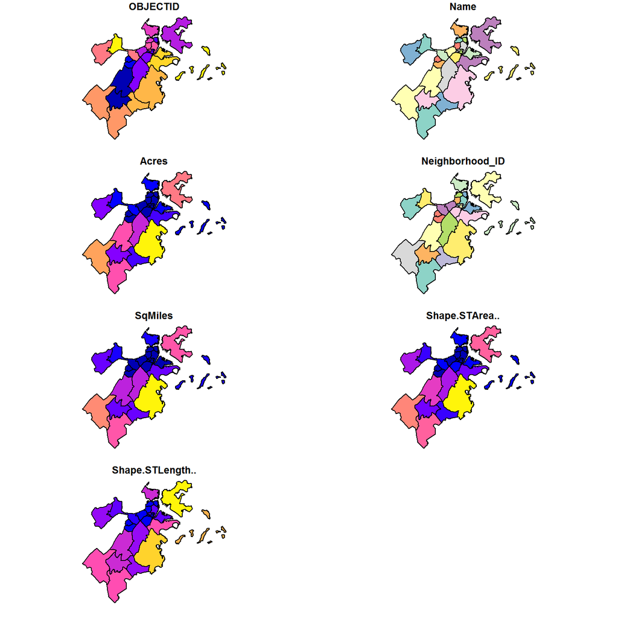

```r
library(esri2sf)
library(sf)

url <- "http://mapservices.bostonredevelopmentauthority.org/arcproxy/arcgis/rest/services/Maps/Orange_Neighb_map/MapServer/0"
bostonHoods <- esri2sf(url)
plot(bostonHoods)
```

## Downloading and wrangling geoJson into R.

Check out this SEPTA station location data on [OpenDataPhilly](https://www.opendataphilly.org/dataset/septa-locations-api%5D). Philadelphia has two subway lines, the “El” or Elevated Subway which runs east to west down Market St., and the Broad St. Line, which runs north to south on Broad St.

The code below will download data for both stations, tag each station by its respective line, `rbind` them together and output a new `sf` data frame.

Note that each API call is a URL. Try to copy and paste the URL into a web browser. The API should return the data in JSON format. In order to convert from JSON to a data frame, we use a package called `jsonlite`.

Note that in the ggplot function below, we are not using `geom_sf` to plot an `sf` object as we have previously. Instead we are using `geom_point`, a native `ggplot` function typically used to create scatterplots. A point map is effectively a scatterplot, although typically we use the color or size aesthetic to show variation across space. Color and fill do not respond as one might expect when using `geom_sf` to map points. Perhaps this is a bug that will be worked out in the future.

```r
library(jsonlite)
#Download El and Broad Street stops
  elStops <- fromJSON("http://arcgis.dvrpc.org/arcgis/rest/services/Transportation/PassengerRailStations/FeatureServer/0/query?where=TYPE+%3D+%27Subway-Elevated%27+AND+COUNTY+%3D+%27Philadelphia%27&objectIds=&time=&geometry=&geometryType=esriGeometryEnvelope&inSR=&spatialRel=esriSpatialRelIntersects&relationParam=&outFields=&returnGeometry=true&maxAllowableOffset=&geometryPrecision=&outSR=&gdbVersion=&returnDistinctValues=false&returnIdsOnly=false&returnCountOnly=false&orderByFields=&groupByFieldsForStatistics=&outStatistics=&returnZ=false&returnM=false&multipatchOption=&f=json")
elStops <- as.data.frame(elStops$features)
elStops <- flatten(elStops)
elStops$Line <- "El"

broadStops <- fromJSON("http://arcgis.dvrpc.org/arcgis/rest/services/Transportation/PassengerRailStations/FeatureServer/0/query?where=TYPE+%3D+%27Subway%27+AND+COUNTY+%3D+%27Philadelphia%27&objectIds=&time=&geometry=&geometryType=esriGeometryEnvelope&inSR=&spatialRel=esriSpatialRelIntersects&relationParam=&outFields=&returnGeometry=true&maxAllowableOffset=&geometryPrecision=&outSR=&gdbVersion=&returnDistinctValues=false&returnIdsOnly=false&returnCountOnly=false&orderByFields=&groupByFieldsForStatistics=&outStatistics=&returnZ=false&returnM=false&multipatchOption=&f=json")
broadStops <- data.frame(broadStops$features)
broadStops <- flatten(broadStops)
broadStops$Line <- "Broad_St"

#Create one data frame
septa <- rbind(elStops,broadStops)
septa.sf <- st_as_sf(septa, coords = c("geometry.x", "geometry.y"), crs = 3857, agr = "constant")
plot(septa.sf[,2])
```

[output not shown]

## Download and wrangling census data with the tidycensus package

The `tidycensus` package is a game changer. You will never have to use the American FactFinder ever again. First go get a Census API code from with web (Please don’t use mine). You can run it with `tidycensus::census_api_key`.

Check out for the documentation for a quick way to find the variables you want to include and which years are included in the package. There is both decennial census and ACS data.

The code block below pulls the data and the geometry. Converts it from long to wide format, renames the variables, mutate some percentages and then plots one variable.

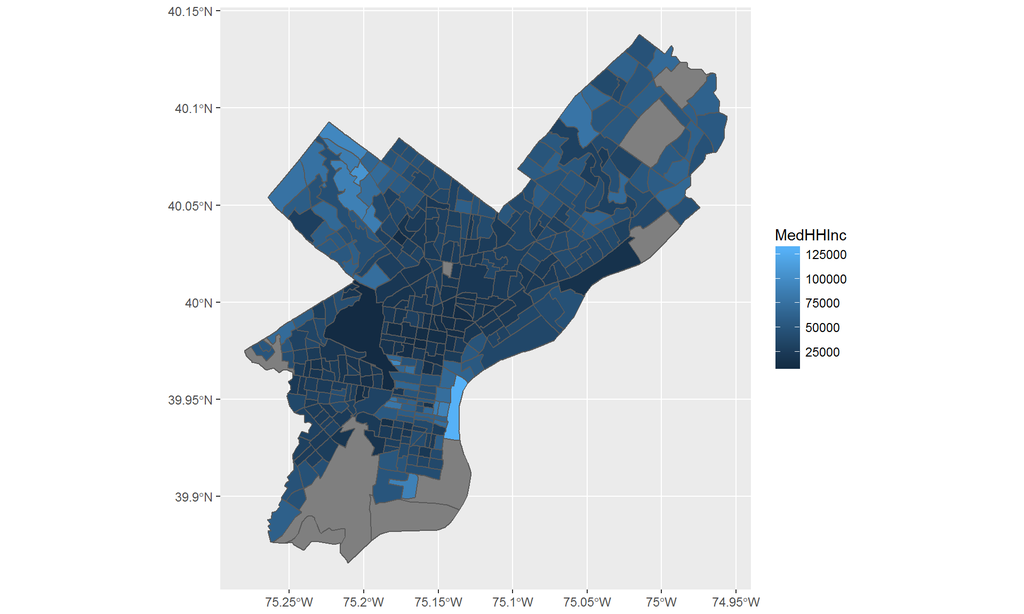

```r
library(tidycensus)
library(tidyverse)

tract10 <-
  get_acs(geography = "tract", variables = c("B25026_001E","B02001_002E","B15001_050E",
                                             "B15001_009E","B19013_001E","B25058_001E",
                                             "B06012_001E"),
          endyear = 2010, state=42, county=101, geometry=T) %>%
  select(variable,estimate) %>%
  as.data.frame() %>%
  spread(variable,estimate) %>%
  rename(TotalPop=B25026_001,
         NumberWhites=B02001_002,
         TotalFemaleBachelors=B15001_050,
         TotalMaleBachelors=B15001_009,
         MedHHInc=B19013_001,
         MedRent=B25058_001,
         TotalPoverty=B06012_001) %>%
  mutate(percentWhite = ifelse(TotalPop > 0, NumberWhites / TotalPop,0),
         percentBachelors = ifelse(TotalPop > 0, ((TotalFemaleBachelors + TotalMaleBachelors) / TotalPop),0),
         percentPoverty = ifelse(TotalPop > 0, TotalPoverty / TotalPop, 0),
         year = "2010") %>%
  select(-NumberWhites,-TotalFemaleBachelors,-TotalMaleBachelors,-TotalPoverty) %>%
  st_sf() %>%
  st_transform(3857)

ggplot() +
   geom_sf(data=tract10, aes(fill=MedHHInc))
```

## Calculating spatial lags

Here we are going to calculate a spatial lag variable. In this case it will generate a new variable that gives, for each observation, the mean price of its 5 nearest neighbor prices.

We’ll use some classic boston data from the `spdep` package. Use `?boston` to learn more about this data. Note that both the data and the routines below rely on the `spdep` package.

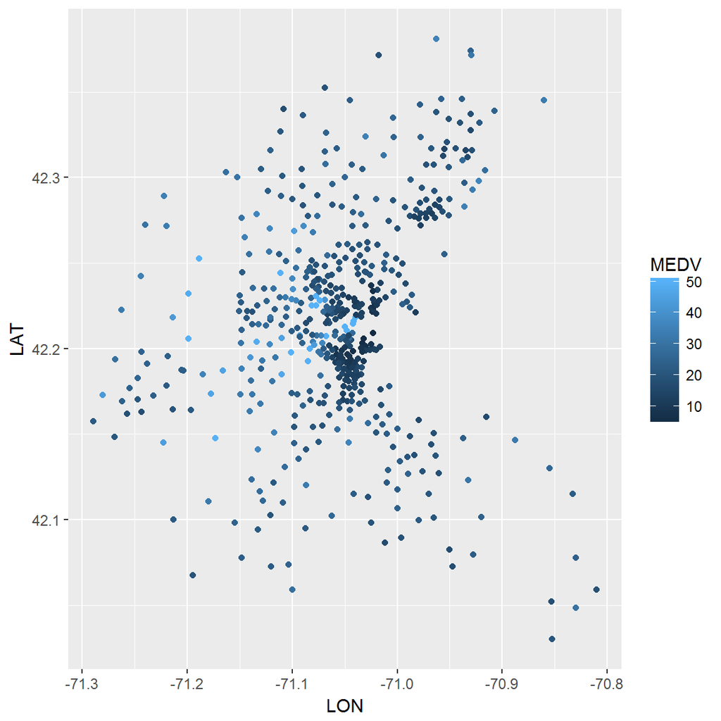

```r
#load the library and the data
library(spdep)
data(boston)

#plot Median Value
ggplot(boston.c, aes(LON,LAT,colour=MEDV)) + geom_point()
```

We create the lag below. Keep in mind if you’re using a `sf` layer, then you can generate xy coordinates using `st_coordinates` to get xy coordinates for each point `geometry`.

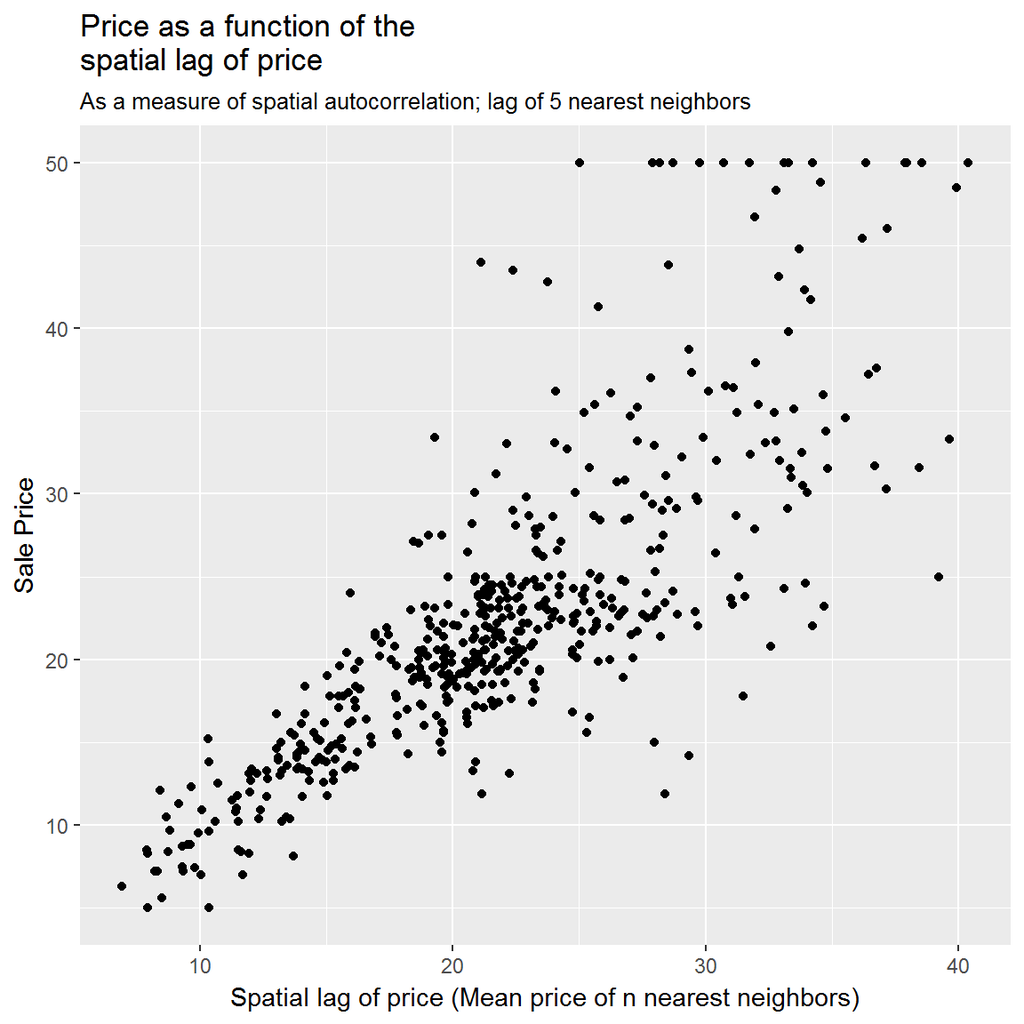

```r
#creata a vector or xy coordinates.
coords <- cbind(boston.c$LON, boston.c$LAT)

#get a vector of 5 nearest neighbor points.
neighborPoints <- knn2nb(knearneigh(coords, 5))

#calculate spaitla weights
spatialWeights <- nb2listw(neighborPoints, style="W")

#create the spatial lag
price.Lag <- lag.listw(spatialWeights, boston.c$MEDV)

#create an outupt data frame
output <- cbind(boston.c,data.frame(lagPrice = price.Lag))

#plot
ggplot(output, aes(lagPrice, MEDV)) +
  geom_point() +
  labs(title = "Price as a function of the\nspatial lag of price",
       subtitle = "As a measure of spatial autocorrelation; lag of 5 nearest neighbors",
       x = "Spatial lag of price (Mean price of n nearest neighbors)",
       y = "Sale Price")
```

## Calculating *k* nearest neighbor distance to other point phenomena

As you know, the variation in something like price is often explained by its distance to other spatial phenomena like crime. In this instance, we’ll create one location, `theCoolPlace`, where everyone wants to be, and create a average nearest neighbor distance variable measuring the distance from each sale to its *k* nearest cool place neighbor. In this case we only have one cool place point, so `k=1`.

You have learned this before, but this time, I have created a function to make it easier for you.

THE EXAMPLE BELOW CALCULATES DISTANCE IN DECIMAL DEGREES.

DO NOT DO THIS!!!!!!

USE DATA PROJECTED IN FEET!

In the code block below, we load the library, create `theCoolPlace` point and map the data

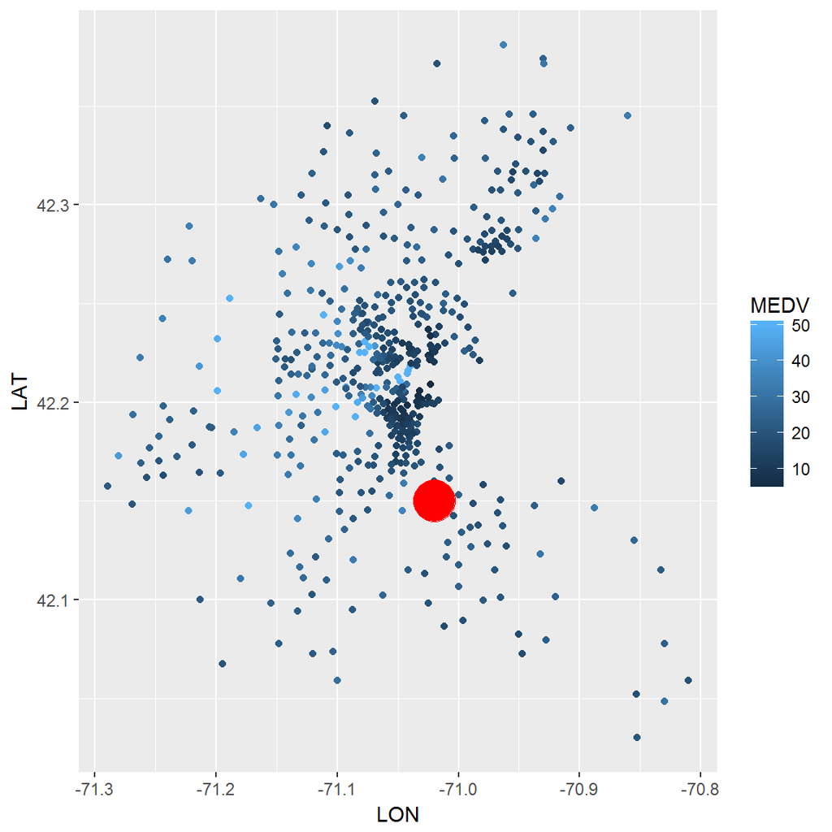

```r
library(FNN)
library(spdep)
data(boston)

theCoolPlace <- data.frame(LON=-71.02,LAT=42.15)

ggplot() +
 geom_point(data=boston.c, aes(LON,LAT,colour=MEDV)) +
 geom_point(data=theCoolPlace, aes(LON,LAT),size=10, colour="red")
```

Create two matrics, one for `bostonXY`, the points we want to `measureFrom` and the other for `coolPlaceXY`, the point we want to `measureTo`.

```r
bostonXY <-
  boston.c %>%
  select(LON,LAT) %>%
  as.matrix()

coolPlaceXY <-
  theCoolPlace %>%
  select(LON,LAT) %>%
  as.matrix()
```

Now the function. I strongly suggest you walk through the dyplyr manually rather than trust it outright. This will help you ensure the calculation is correct. Note we’re only using `k=1` here so, `mean(point_distance)` is a bit extraneous.

```r
nn_function <- function(measureFrom,measureTo,k) {

nn <-
  get.knnx(measureTo, measureFrom, k)$nn.dist

output <-
  as.data.frame(nn) %>%
  rownames_to_column(var = "thisPoint") %>%
  gather(points, point_distance, V1:ncol(.)) %>%
  arrange(as.numeric(thisPoint)) %>%
  group_by(thisPoint) %>%
  summarize(pointDistance = mean(point_distance)) %>%
  arrange(as.numeric(thisPoint)) %>%
  select(-thisPoint)

return(output)
  }
```

Now run the function and `cbind` the average distance to the boston data and map.

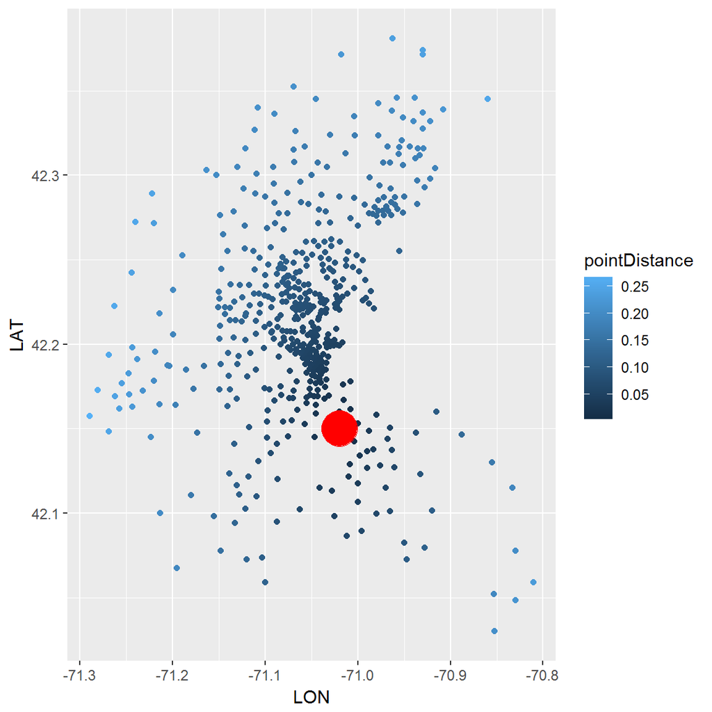

```r
coolPlaceDistance <- nn_function(bostonXY,coolPlaceXY,1)

output <- cbind(boston.c, coolPlaceDistance)

ggplot() +
 geom_point(data=output, aes(LON,LAT,colour=pointDistance)) +
 geom_point(data=theCoolPlace, aes(LON,LAT), size=10, colour="red")
```

## Downloading OSM data in to R

In this section we will use the `osmdata` package to download OpenStreetMap data, convert to sf and map

To begin, we need to define a spatial bounding box that we will use to grab some data. You can check out http://boundingbox.klokantech.com/ to get coordinates for your own custom bounding box area.

We will then grab the Philadelphia boundary and plot.

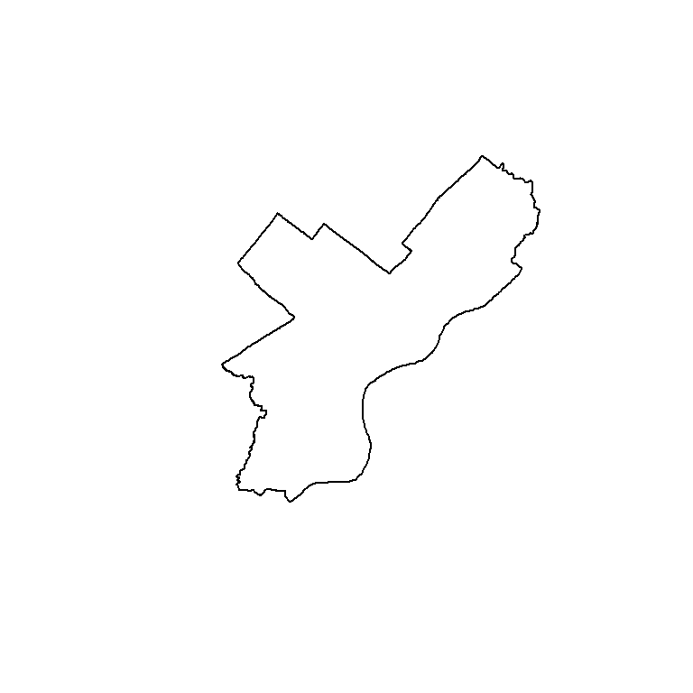

```r
library(osmdata)
library(sf)

# define a bounding box
q0 <- opq(bbox = c(-75.338789,39.846501,-74.955763,40.166279))

q1 <- add_osm_feature(opq = q0, key = 'name', value = "Philadelphia")
res1 <- osmdata_sf(q1)
phila <- st_geometry(res1$osm_multipolygons[1,])


plot(phila)
```

Let’s grab some parks and plot. Note that these are simple features.

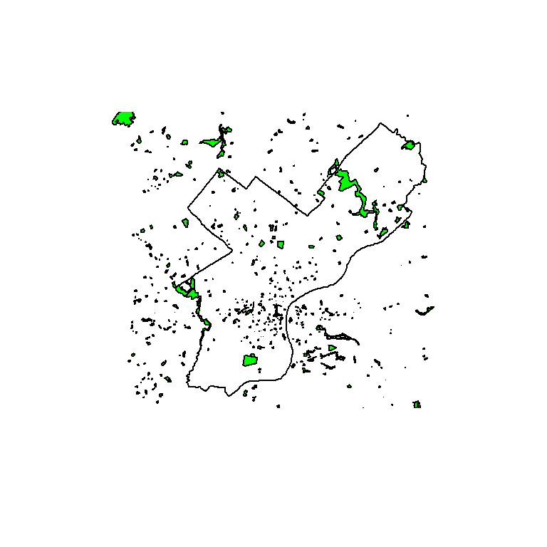

```r
q3 <- add_osm_feature(opq = q0, key = 'leisure', value = "park")
res3 <- osmdata_sf(q3)
parks <- st_geometry(res3$osm_polygons)

plot(phila)
plot(parks, add=T, col="green")
```

Let’s download Septa stations and restaurants. Notice that all the points of interest are catagorized by `key` and `value`. You can find a full list of these here. https://wiki.openstreetmap.org/wiki/Map_Features.

Note that “restaurant” might only be a subgroup of what you are actually looking for like “bars”, for instance.

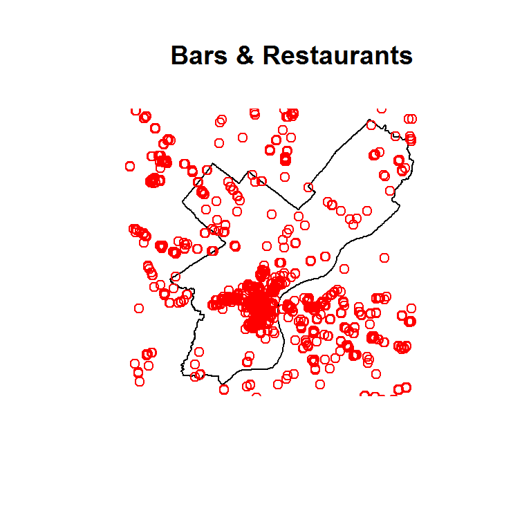

```r
q8 <- add_osm_feature(opq = q0, key = 'station', value = "subway")
res8 <- osmdata_sf(q8)
septa <- res8$osm_points

q9 <- add_osm_feature(opq = q0, key = 'amenity', value = "restaurant")
res9 <- osmdata_sf(q9)
resto <- res9$osm_points

plot(phila,main = "Bars & Restaurants")
plot(resto, add=T, col="red")
```

Now project we project the data in to state plan, “clip” by philadelphia using `st_intersection` and convert to sf (from geometry set).

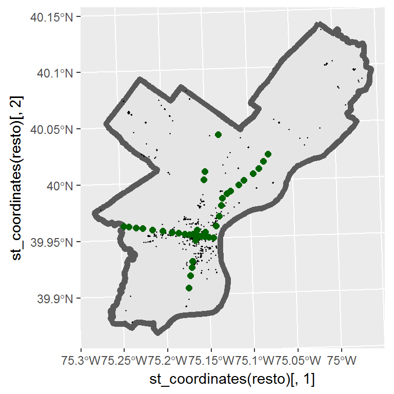

```r
phila <-
 phila %>%
 st_transform(crs=2272) %>%
 st_sf()

septa <-
  septa %>%
  st_transform(crs=2272) %>%
  st_intersection(phila) %>%
  st_sf()

resto <-
  resto %>%
  st_transform(crs=2272) %>%
  st_intersection(phila) %>%
  st_sf()

ggplot() +
  geom_sf(data=phila, size=2) +
  geom_point(data=resto, aes(st_coordinates(resto)[,1], st_coordinates(resto)[,2]), size=0.2) +
  geom_point(data=septa, aes(st_coordinates(septa)[,1], st_coordinates(septa)[,2]), size=2, color="darkgreen")
```

How would you add a legend that would indicate septa vs. restaurant points?

## Spatial joining

Here is how to do a spatial join in `sf`. **You need version of 0.6 of `sf` for this.** First we’ll create some point and polygon data. Note that the polygon has two `types`.

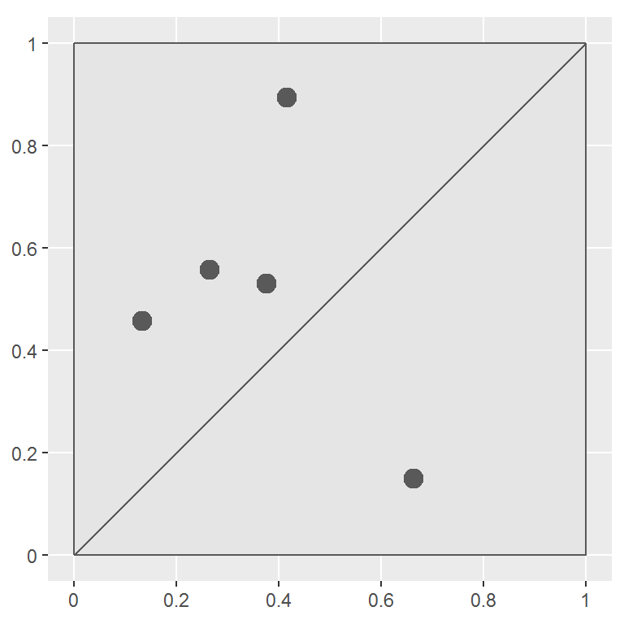

```r
#create polygon
m1 = cbind(c(0, 0, 1, 0), c(0, 1, 1, 0))
m2 = cbind(c(0, 1, 1, 0), c(0, 0, 1, 0))
m3 = data.frame(type=c("smellyPlace","freshPlace"))
polygon = st_sfc(st_polygon(list(m1)), st_polygon(list(m2))) %>%  st_sf %>% bind_cols(m3)

#create points
set.seed(1985)
d = data.frame(matrix(runif(15), ncol = 3))
points = st_as_sf(x = d, coords = 1:2)

#plot
ggplot() + geom_sf(data=polygon) + geom_sf(data=points)
```

Now wee spatial join. Here we are just generating the count of points using `length`, but if you wanted to calculate the average of input points for instance, you could use `mean`.

```r
joinPointsToPolys <-
  aggregate(points, polygon, length) %>%
  bind_cols(polygon) %>%
  select(X3,type)

joinPointsToPolys
```

```
## Simple feature collection with 2 features and 2 fields
## geometry type:  POLYGON
## dimension:      XY
## bbox:           xmin: 0 ymin: 0 xmax: 1 ymax: 1
## epsg (SRID):    NA
## proj4string:    NA
##   X3        type                       geometry
## 1  4 smellyPlace POLYGON ((0 0, 0 1, 1 1, 0 0))
## 2  1  freshPlace POLYGON ((0 0, 1 0, 1 1, 0 0))
```

Let’s plot the counts. You should probably change the name from `X3` to `count`.

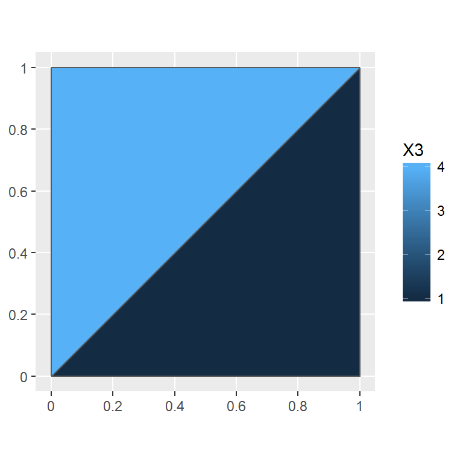

```r
ggplot() + geom_sf(data=joinPointsToPolys, aes(fill=X3))
```

## Kernel Density

Unfortunately the functionality that creates kernel density in R uses old technology - specifically the `spatstat` and `sp` packages. `Spatstat` on its own offers some really important statsitics tools for ‘point processes’ but it uses its own class known as `ppp`.

`ppp` does not work in neither a `tidyverse` nor `sf` context. You see below, how we convert back and forth to enable us to plot in `ggplot`.

Finally, note that we convert the kernel density created by `spatstat` into a raster using the `raster` package.

We begin by creating some points. Note that we have to manually set a `window` which is the spatial extent of our points. Here I create `points` and `points.sf` which we use farther down. We then convert the `points` to `ppp` and plot the density with the points overlayed.

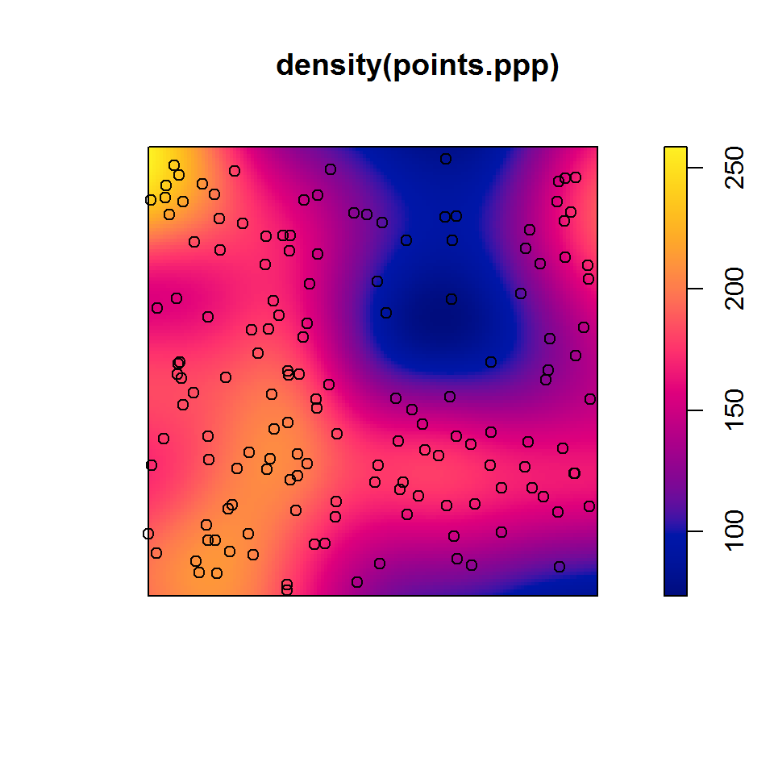

```r
library(spatstat)
library(raster)
library(rasterVis)
library(sf)

#create points
set.seed(1985)
points = data.frame(matrix(runif(300), ncol = 2))
points.sf = st_as_sf(x = points, coords = 1:2)
window <- owin(c(0,1), c(0,1))

#convert points to ppp
points.ppp <- as.ppp(points,window)

#plot
plot(density(points.ppp))
plot(points.ppp,add=T)
```

Next we convert our density to a `raster` which is a class unto itself and we plot the raster using the `gplot` function (note the one “g”). `gplot` is a wrapper for `ggplot` designed to handle raster data.

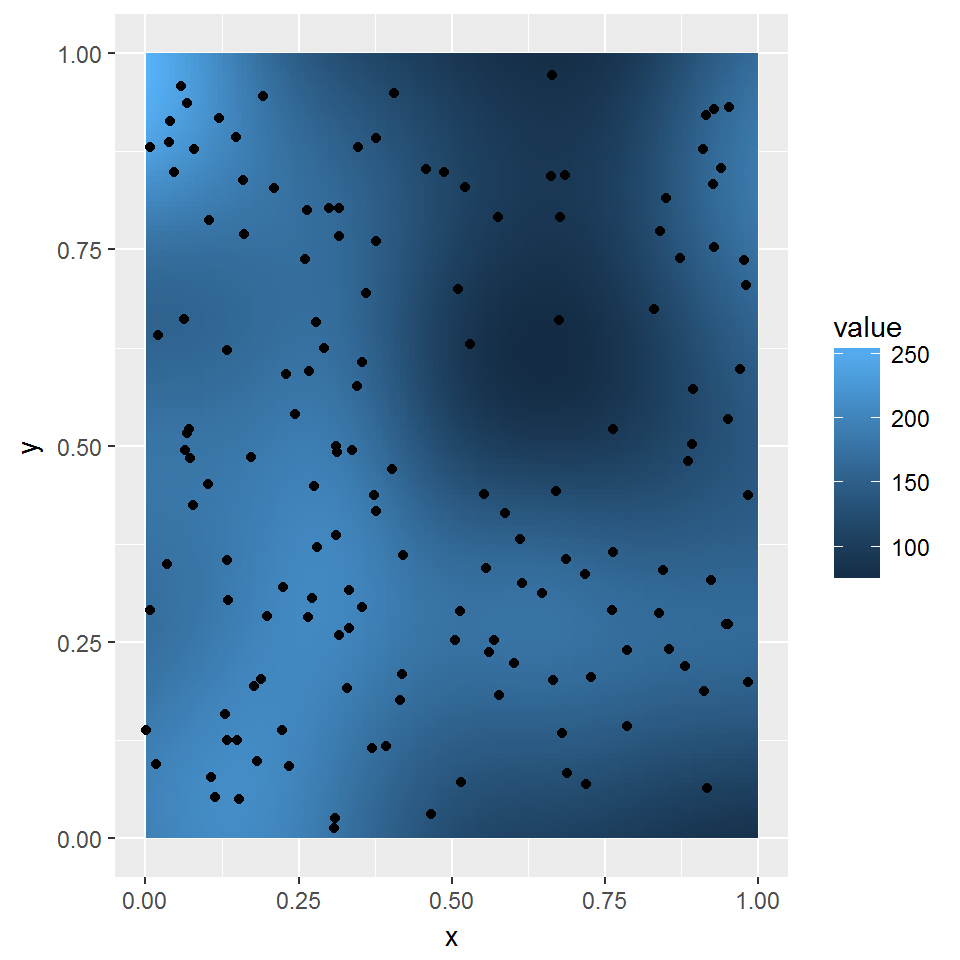

```r
densityRaster <- raster(density(points.ppp))

gplot(densityRaster) +
  geom_raster(aes(fill = value)) +
  geom_point(data=points, aes(X1,X2))
```

Let’s do it again but this time we add all the `ggplot` bells and whistles.

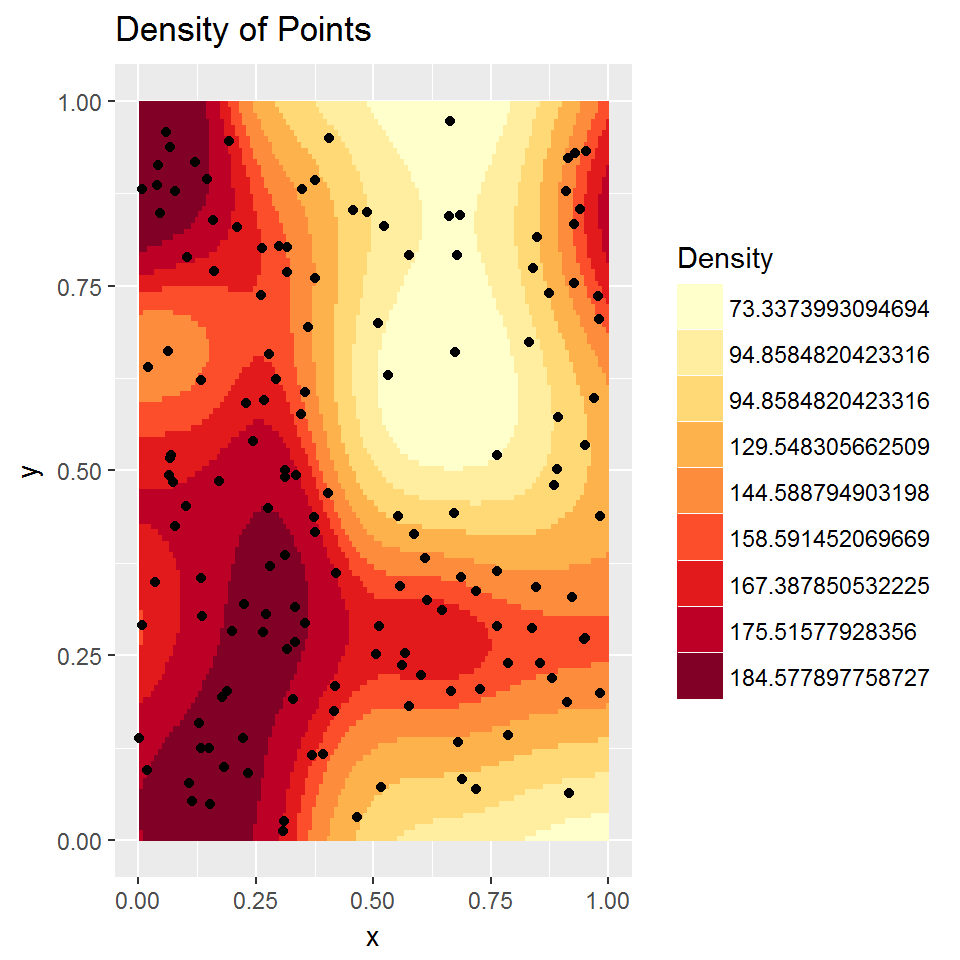

```r
gplot(densityRaster) +
  geom_raster(aes(fill = as.factor(ntile(value,9)))) +
  geom_point(data=points, aes(X1,X2)) +
  scale_fill_manual(values = c("#ffffcc","#ffeda0","#fed976","#feb24c","#fd8d3c","#fc4e2a","#e31a1c","#bd0026","#800026"),
                    labels=as.character(quantile(getValues(densityRaster),
                                                 c(0,.1,.1,.3,.4,.5,.6,.7,.8),na.rm=T)),
                    name="Density") +
  labs(title="Density of Points")
```

Next, we demonstrate how to “clip” out a raster by way of a polygon. We create a singular circular polygon by selecting a random point from points.sf, buffering it and converting it to `sp`. Using the `mask` function, a new raster is created which we then plot.

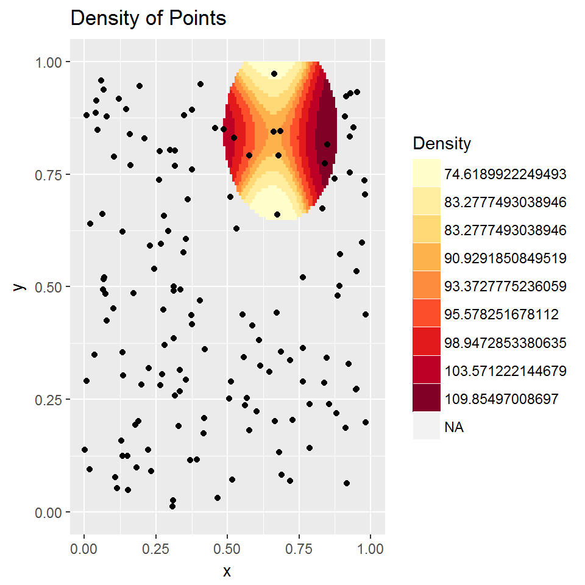

```r
#Create a polygn
buffer <- st_buffer(points.sf[25,],.2)
buffer <- as(buffer, 'Spatial')
buffer <- as(buffer, 'SpatialPolygons')

#mask
clip_Raster_byBuffer <- mask(densityRaster, buffer)

#plot
gplot(clip_Raster_byBuffer) +
  geom_raster(aes(fill = as.factor(ntile(value,9)))) +
  geom_point(data=points, aes(X1,X2)) +
  scale_fill_manual(values = c("#ffffcc","#ffeda0","#fed976","#feb24c","#fd8d3c","#fc4e2a","#e31a1c","#bd0026","#800026"),
                    labels=as.character(quantile(getValues(clip_Raster_byBuffer),
                                                 c(0,.1,.1,.3,.4,.5,.6,.7,.8),na.rm=T)),
                    name="Density") +
  labs(title="Density of Points")
```

Finally note that you can extract the raw grid cell density data by a polygon and do some arithmetic, like take the mean. This is especialy nice if you wanted to use density as an indpendent variable and wanted mean density by fishnet grid cell.

Here, we create two random buffer polygons, convert to `sp` and extract the raster values setting `fun=mean`, which will return the mean density for those two polygons.

```r
buffer2 <-
  points.sf %>%
  sample_n(2) %>%
  st_buffer(.2) %>%
  as('Spatial') %>%
  as('SpatialPolygons')

extract_Raster_byBuffer <- extract(densityRaster, buffer2,fun=mean)

extract_Raster_byBuffer
```

```
##          [,1]
## [1,] 148.3142
## [2,] 158.5582
```

## Mapping `sf` points with `geom_point`.

Using the ‘septa.sf’ layer from above, note how `ggplot2` treats points in `geom_sf`.

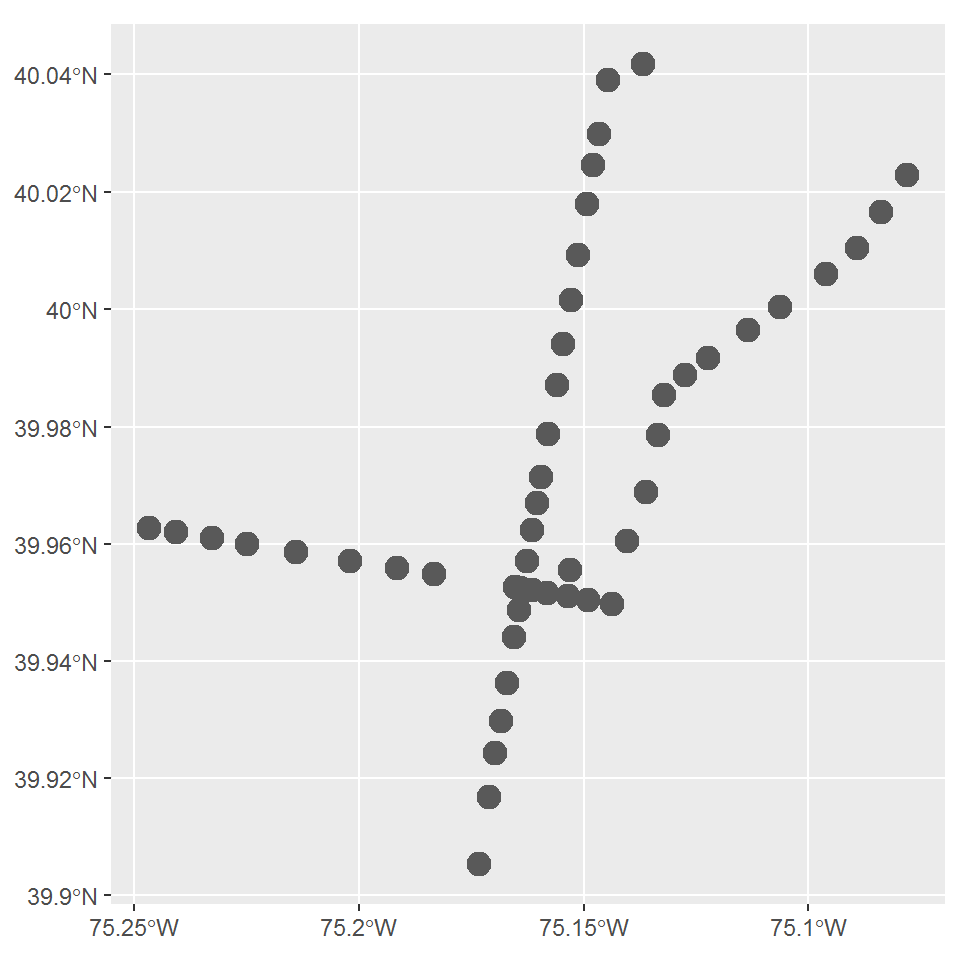

```r
library(tidyverse)
library(sf)

ggplot()+
  geom_sf(data=septa.sf, aes())
```

What happens if I try to change the point size to something really small?

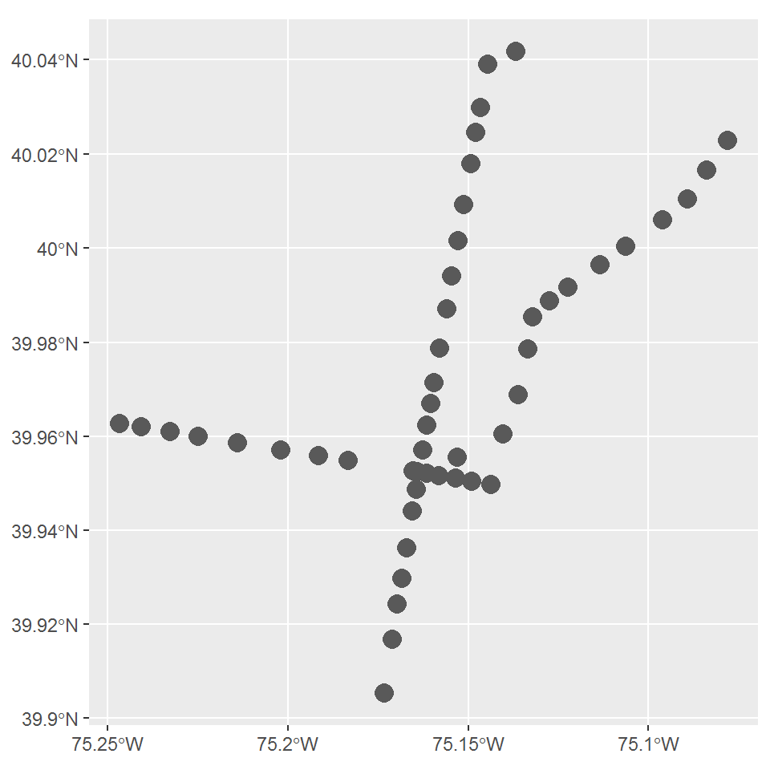

```r
ggplot()+
  geom_sf(data=septa.sf, aes(), size=.1)
```

As I mentioned in the OSM section above, the best approach to is use `geom_point` by converting to coordinates like so:

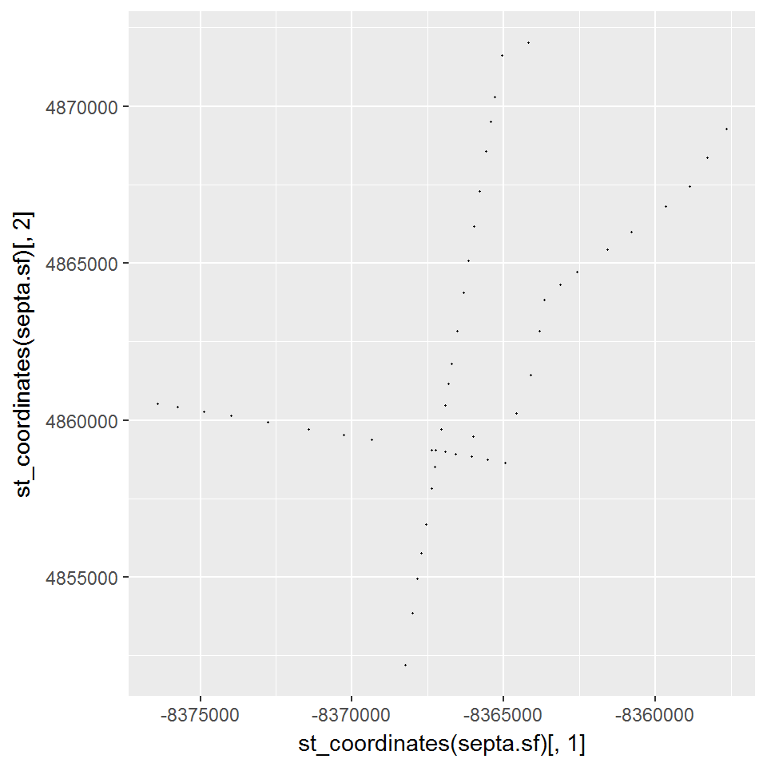

```r
ggplot()+
  geom_point(data=septa.sf, aes(st_coordinates(septa.sf)[,1],
                                st_coordinates(septa.sf)[,2]),
                            size=0.2)
```

Just an aside, say that you have 500k points that you want to map. Ggplot will take a while to plot that many points. You can wait that long for your final markdown, but if you’re just trying to figure out the cartography then only plot a subset of points like so.

Here I create a smaller dataset and plot.

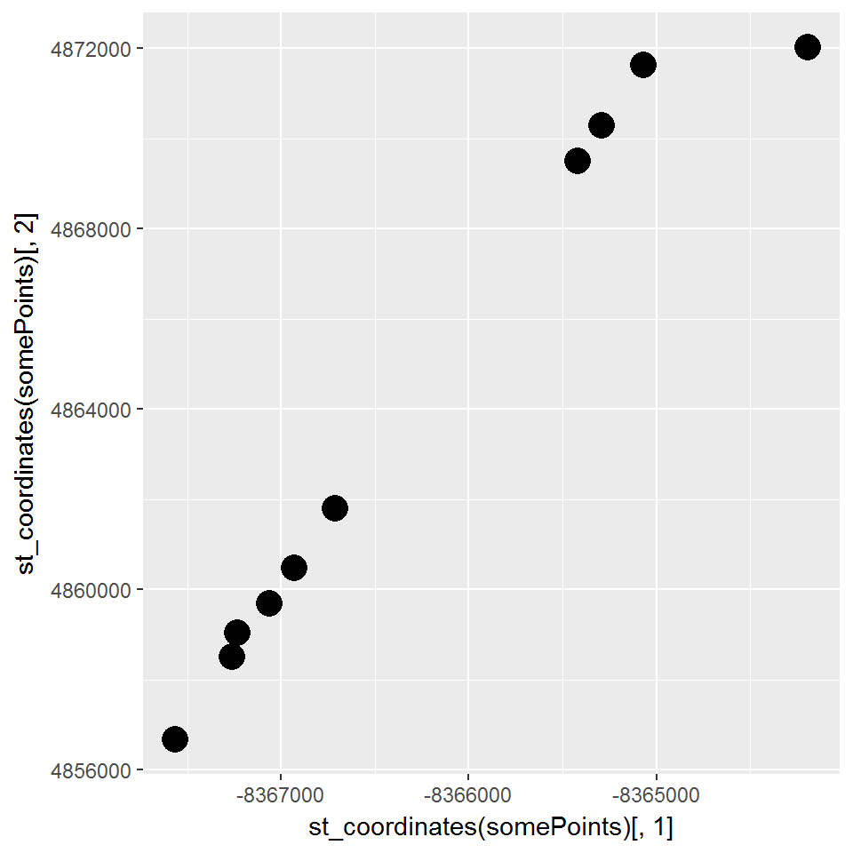

```r
somePoints <- septa.sf %>% top_n(10)

ggplot()+
  geom_point(data=somePoints, aes(st_coordinates(somePoints)[,1],
                                st_coordinates(somePoints)[,2]),
                              size=5)
```

## Small multiple plots using grid.arrange

You all know how small multiples work. Typically, these plots are built with `facet_wrap` or `facet_grid` in `ggplot`. However, we’re going to learn how to do this with the `gridExtra` package which provides flexibility in a couple of ways.

First, unlike facetting, `gridExtra` allows you to create small multiple plots with varying scales. Second, and perhaps more importantly, you can create small multiple plots that include different plot types. Using the Boston data from above:

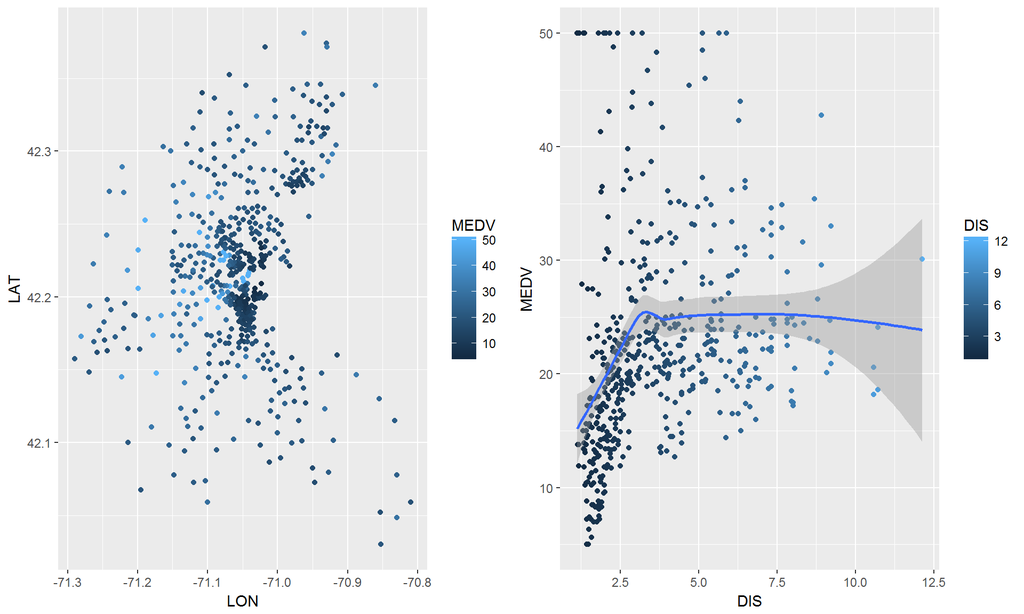

```r
library(gridExtra)
data(boston)

scatter <- ggplot(boston.c, aes(DIS,MEDV,colour=DIS)) + geom_point() + geom_smooth(method="loess")
map <- ggplot(boston.c, aes(LON,LAT, colour=MEDV)) + geom_point()

grid.arrange(map,scatter, ncol=2)
```

You can see that both plots now both have legends. Would it look better if we moved the legends to the bottom?

How about lay something out like this?

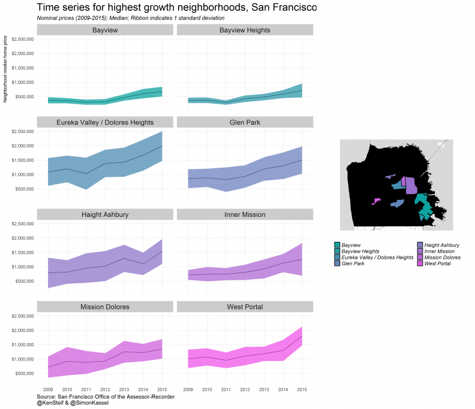

To create a more complicated layout, we create a custom layout matrix and slot four plots into it. I’m not sure why so much space is being output.

```r
library(gridExtra)
library(grid)

scatter <- ggplot(boston.c, aes(DIS,MEDV,colour=DIS)) + geom_point() + geom_smooth(method="loess")
scatter2 <- ggplot(boston.c, aes(CRIM,MEDV,colour=CRIM)) + geom_point() + geom_smooth(method="loess")
scatter3 <- ggplot(boston.c, aes(NOX,MEDV,colour=NOX)) + geom_point() + geom_smooth(method="loess")
map <- ggplot(boston.c, aes(LON,LAT, colour=MEDV)) + geom_point()

blank <- grid.rect(gp=gpar(col="white"))
```

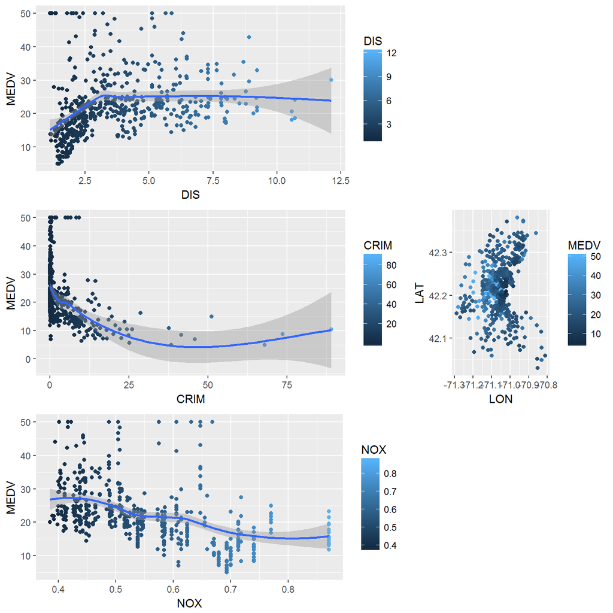

```r
thePlots <- list(blank,scatter,scatter2,scatter3,map)

lay <- rbind(c(2,2,1),
             c(3,3,5),
             c(4,4,1))

grid.arrange(grobs = thePlots, layout_matrix = lay)
```

## Local moran’s I

Many of you want to know if your data is clustered at more local levels. While Moran’s I will give you “global” clustering, the Local Moran’s I will provide you with an indication of local clustering by providing statistical significance. We use the Boston data to illustrate.

1. Create a matrix of your coordinates. (Not sure why markdown is requiring me to specify that I’m using `dplyr::select`)
2. Create a spatial weights matrix using 5 nearest neighbors. Here we need to combine `knearneigh` and `nb2listw`.
3. Calcuate Local Moran’s I, `cbind` back to the oringal data frame and change the awkwardly named pvalue column for plotting.
4. Create 3 plots for the original home value, the I value and the I p-value. Then `grid.arrange` them into one plot.

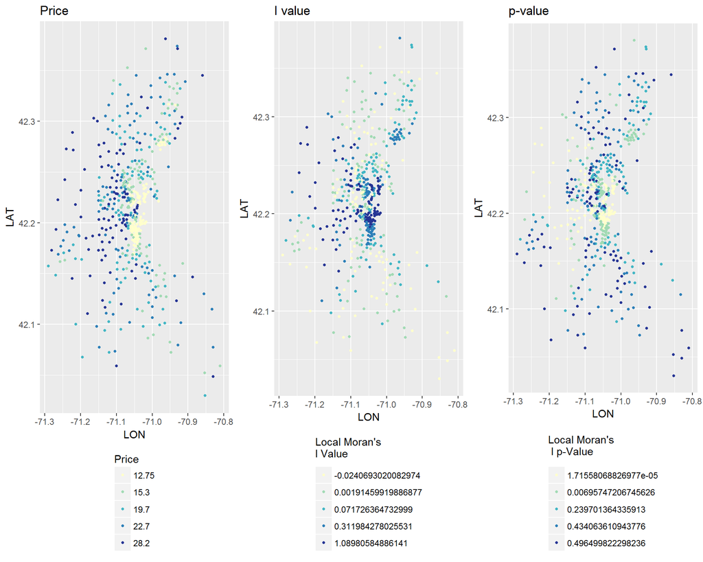

```r
library(tidyverse)
library(spdep)

data(boston)

#coordintates
bostonCoords <-
  boston.c %>%
  dplyr::select(LAT,LON) %>%
  as.matrix()

#Create nearest neighbor and spatial weights and then caluclate the statistic.
neighborPointsBoston <- knn2nb(knearneigh(bostonCoords, 5))
spatialWeights <- nb2listw(neighborPointsBoston, style="W")
localMorans <- as.data.frame(localmoran(boston.c$MEDV, spatialWeights))

#join back
boston.c <- cbind(boston.c, localMorans)
boston.c$pvalue <- boston.c[,25]

ValuePlot <-
  ggplot(boston.c, aes(LON,LAT,colour = factor(ntile(MEDV,5))) ) +
  geom_point(size=1) +
  scale_colour_manual(values = c("#ffffcc","#a1dab4","#41b6c4","#2c7fb8","#253494"),
                      labels=as.character(quantile(boston.c$MEDV,
                                                   c(.1,.2,.4,.6,.8),na.rm=T)),
                      name="Price") +
 labs(title="Price") +
 theme(legend.position="bottom",legend.direction="vertical")

localMoranIPlot <-
  ggplot(boston.c, aes(LON,LAT,colour = factor(ntile(Ii,5)))) +
  geom_point(size=1) +
  scale_colour_manual(values = c("#ffffcc","#a1dab4","#41b6c4","#2c7fb8","#253494"),
                      labels=as.character(quantile(boston.c$Ii,
                                                   c(.1,.2,.4,.6,.8),na.rm=T)),
                      name="Local Moran's\nI Value") +
 labs(title="I value") +
 theme(legend.position="bottom",legend.direction="vertical")

localMoranPValPlot <-
  ggplot(boston.c, aes(LON,LAT,colour = factor(ntile(pvalue,5)))) +
  geom_point(size=1) +
  scale_colour_manual(values = c("#ffffcc","#a1dab4","#41b6c4","#2c7fb8","#253494"),
                      labels=as.character(quantile(boston.c$pvalue,
                                                   c(.1,.2,.4,.6,.8),na.rm=T)),
                      name="Local Moran's\n I p-Value")  +
 labs(title="p-value") +
 theme(legend.position="bottom",legend.direction="vertical")

grid.arrange(ValuePlot,localMoranIPlot,localMoranPValPlot, ncol=3)
```

Maybe it makes sense to create a plot of just those statistically significant points. What would be the best way to represent this cartographically?

## Moran’s I with simulation

You should all know what Moran’s I is testing for. Let’s calculate it in R but using a simulation approach.

The best way to understand if a spatial process is clustered or otherwise, is to form a hypothesis test that compares our observed price pattern to a randomly permuted price pattern. Using the `moran.mc` (“mc” stands for monte carlo simulation), we create 999 random permutations of `MEDV`, calculating Moran’s I at each iteration. At each permutation, the geometry of the points stay fixed but the sale prices are randomly assigned to different points. Like so:

```r
moranTest <- moran.mc(boston.c$MEDV, spatialWeights,nsim = 999)
moranTest
```

```
##
##  Monte-Carlo simulation of Moran I
##
## data:  boston.c$MEDV
## weights: spatialWeights
## number of simulations + 1: 1000
##
## statistic = 0.59257, observed rank = 1000, p-value = 0.001
## alternative hypothesis: greater
```

As you can see the results indicate we have statistically significant clustering. Let’s look a bit more under the hood to plot all the simulation results from our random permutations.

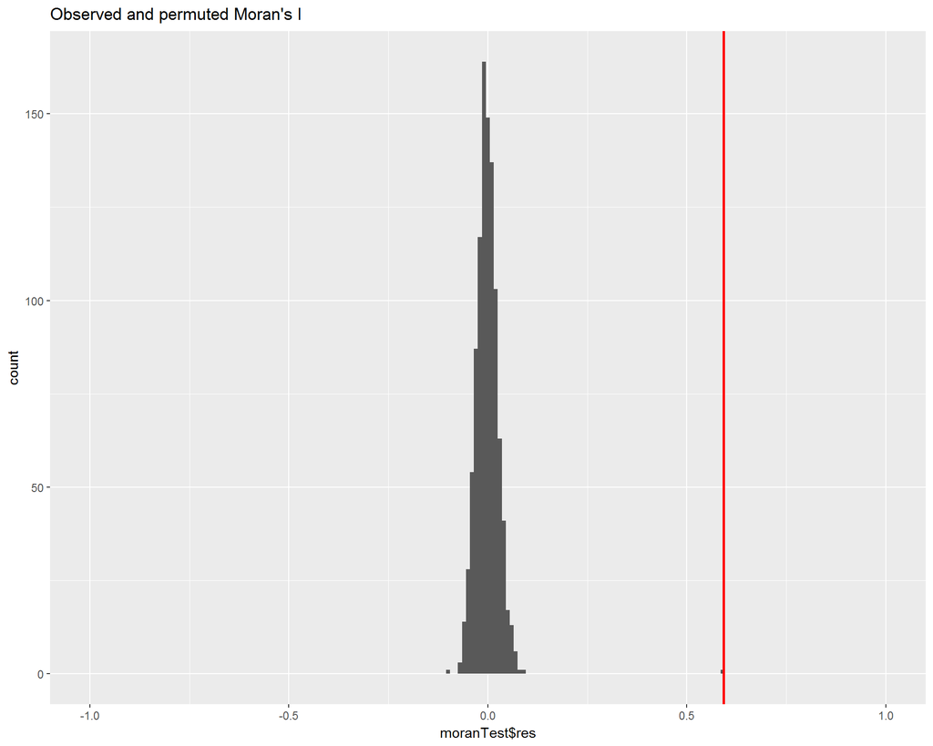

```r
ggplot(as.data.frame(moranTest$res), aes(moranTest$res)) +
  geom_histogram(binwidth = 0.01) +
  geom_vline(aes(xintercept = 0.5925738279), colour = "red",size=1) +
  scale_x_continuous(limits = c(-1, 1)) +
  labs(title="Observed and permuted Moran's I")
```

What does the histogram represent? What does the red line represent? What makes this a useful of understanding statistical significance?

## Keeping track of your models

You are going to be creating lots of models. Here is how you can create a formatted table keeping track of the type of model and related goodness of fit metrics.

Here I am using the caret `train` function that everyone shoudl be using. I have not specified the `ctrl` parameter that defines cross-validation, but you should.

```r
library(caret)
library(knitr)

data(mtcars)
regCars <- train(mpg~.,data=mtcars,method="lm")
regCarsMAPE <- (mtcars$mpg - (predict(regCars,mtcars))) / mtcars$mpg

resultsTable <- data.frame(modelNum = 1,
                           modelName= "regCars",
                           Description = "Linear Model; All the features",
                           R2 = regCars$results[,3],
                           avg_MAE = regCars$results[,4],
                           sd_MAE = regCars$results[,7],
                           MAPE = mean(regCarsMAPE),
                           pred_moransI = 0,
                           pred_moransI_P = 0,
                           err_MoransI = 0,
                           err_MoransI_P = 0)

kable(resultsTable)
```

| modelNum | modelName | Description | R2 | avg_MAE | sd_MAE | MAPE | pred_moransI | pred_moransI_P | err_MoransI | err_MoransI_P |
| --- | --- | --- | --- | --- | --- | --- | --- | --- | --- | --- |
| 1 | regCars | Linear Model; All the features | 0.5845823 | 3.833441 | 1.336422 | -0.0085691 | 0 | 0 | 0 | 0 |

Now if you want to add another model to this, you would simply `rbind` another row to the table.

```r
library(dplyr)

regCars2 <- train(mpg~.,data=mtcars %>% dplyr::select(-hp),method="lm")
regCars2MAPE <- (mtcars$mpg - (predict(regCars2,mtcars))) / mtcars$mpg

resultsTable <-
  rbind(resultsTable,
    data.frame(modelNum = 2,
               modelName= "regCars2",
               Description = "Linear Model; No `hp` variable",
               R2 = regCars2$results[,3],
               avg_MAE = regCars2$results[,4],
               sd_MAE = regCars2$results[,7],
               MAPE = mean(regCars2MAPE),
               pred_moransI = 0,
               pred_moransI_P = 0,
               err_MoransI = 0,
               err_MoransI_P = 0)
    )
kable(resultsTable)
```

| modelNum | modelName | Description | R2 | avg_MAE | sd_MAE | MAPE | pred_moransI | pred_moransI_P | err_MoransI | err_MoransI_P |
| --- | --- | --- | --- | --- | --- | --- | --- | --- | --- | --- |
| 1 | regCars | Linear Model; All the features | 0.5845823 | 3.833441 | 1.3364221 | -0.0085691 | 0 | 0 | 0 | 0 |
| 2 | regCars2 | Linear Model; No `hp` variable | 0.6532951 | 3.262537 | 0.8654566 | -0.0088553 | 0 | 0 | 0 | 0 |

## Caret’s train function

This is the best approach for tuning the hyperparamters of R models. Period.

Using the `BostonHousing2` dataset from the `mlbench` package, I demonstrate below.

First, let’s split the data into training and test. Then we specify the kind of cross-validation. And finally, `train` our model. Note that if you want to change the model type, you simple change `method`. [Here is a list of available models.](https://topepo.github.io/caret/available-models.html)

What makes `caret` so powerful, is that it’s doing cross-validation, such that at every fold, it’s trying different hyperparamter values.

```r
library(tidyverse)
library(mlbench)
data(BostonHousing2)

#split
set.seed(123)
sampleSize <- floor(0.75 * nrow(BostonHousing2))
train_index <- sample(seq_len(nrow(BostonHousing2)), size = sampleSize)
train <- BostonHousing2[train_index, ]
test <- BostonHousing2[-train_index, ]

# 10-fold CV
fitControl <- trainControl(method = "repeatedcv",number = 10)

#now fit gbm using train
set.seed(825)
gbmFit1 <- train(cmedv ~ .,
                 method = "gbm",
                 trControl = fitControl,
                 verbose = FALSE,
                 data = train %>%
                        dplyr::select(-lon,-lat,-medv)
                 )
gbmFit1
```

```
## Stochastic Gradient Boosting
##
## 379 samples
##  15 predictor
##
## No pre-processing
## Resampling: Cross-Validated (10 fold, repeated 1 times)
## Summary of sample sizes: 342, 341, 340, 342, 340, 341, ...
## Resampling results across tuning parameters:
##
##   interaction.depth  n.trees  RMSE      Rsquared   MAE
##   1                   50      4.213078  0.7918181  2.906906
##   1                  100      3.880429  0.8174772  2.647871
##   1                  150      3.800913  0.8226922  2.583099
##   2                   50      3.885913  0.8191308  2.590586
##   2                  100      3.681218  0.8366565  2.402922
##   2                  150      3.601330  0.8447216  2.360116
##   3                   50      3.628628  0.8417212  2.405374
##   3                  100      3.416254  0.8612080  2.270505
##   3                  150      3.339491  0.8664975  2.232181
##
## Tuning parameter 'shrinkage' was held constant at a value of 0.1
##
## Tuning parameter 'n.minobsinnode' was held constant at a value of 10
## RMSE was used to select the optimal model using the smallest value.
## The final values used for the model were n.trees = 150,
##  interaction.depth = 3, shrinkage = 0.1 and n.minobsinnode = 10.
```

Note that if you’re doing a binary outcome, and you want AUC as a goodness of fit metric, you can feed `train` a custom function [like this](https://stackoverflow.com/questions/37666516/caret-package-custom-metric).

`summary(gbmFit1)` gives variable importance.

Next, check out `names(gbmFit1)`. Try `gbmFit1$finalModel` to see the final model and `gbmFit1$resample` to see the cv result.

Now if you want to know if your final model is stable to random holdouts, you have to do further cross-validation. This is to say that `train` does cv to tune hyperparamters, but we also want to know if we get stable goodness of fit across random holdouts.

Below is a function adopted from [here](https://stats.stackexchange.com/questions/61090/how-to-split-a-data-set-to-do-10-fold-cross-validation), that will do 100 fold cross validation. Here I am using a `lm` model, but you want to insert your final model from `train`. Note that for a gbm model, you can use the `gbm` package to run the model in the function. You would retrieve the tuned hyperparameters with `gbmFit1$bestTune`.

Note that I’ve hardwired some parameters in to this for loop.

```r
#Randomly shuffle the data
train2 <- train[sample(nrow(train)),]

#Create 100 equally size folds
folds <- cut(seq(1,nrow(train)),breaks=100,labels=FALSE)

#Perform 100 fold cross validation
endList <- data.frame()
for(i in 1:100){
    #Segement your data by fold using the which() function
    testIndexes <- which(folds==i,arr.ind=TRUE)
    testData <- train[testIndexes, ]
    trainData <- train[-testIndexes, ]

    #Using your pre trained model, predict - note I have hardwired `gbmFit1` here.
    thisTrain <- lm(trainData$cmedv ~ ., data = trainData %>%
                                                dplyr::select(-medv,-town))
    thisPrediction <- predict(thisTrain, testData)

   #calculate mape and mae. Note that I have hardwired the dependent variable here.
   thisMAPE <- mean(abs(testData$cmedv - thisPrediction) / testData$cmedv )
   thisMAE <- mean(abs(testData$cmedv  - thisPrediction))

   #cbind this folds MAPE and MAE
   thisList <- cbind(thisMAPE, thisMAE)

   #add to the final MAPE and MAE list

   #print
   endList <- rbind(endList, thisList)
   result <- endList
}

head(result)
```

```
##     thisMAPE   thisMAE
## 1 0.18556483 1.4854372
## 2 0.03182610 0.6890031
## 3 0.12964246 3.7002166
## 4 0.06104504 1.9750422
## 5 0.11335759 2.8067296
## 6 0.14093396 2.3462029
```

Here we are only printing the first 6 cv results, but `result` is 100 rows long. Now we plot this as a histogram.

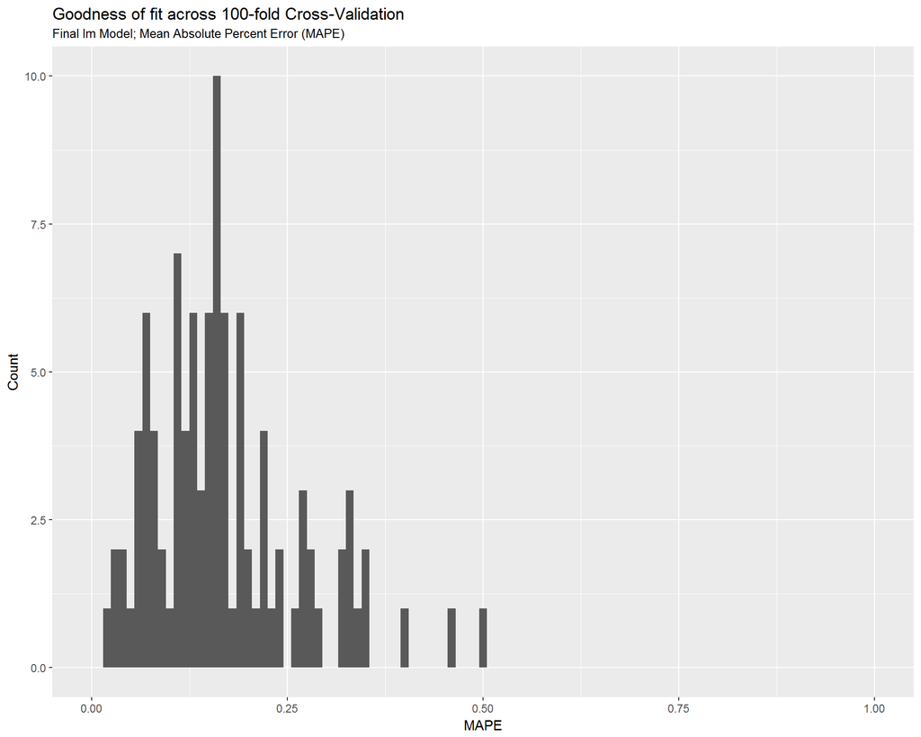

```r
library(tidyverse)

ggplot(result, aes(thisMAPE)) +
  geom_histogram(binwidth = .01) +
  scale_x_continuous(limits = c(0, 1)) +
  labs(title="Goodness of fit across 100-fold Cross-Validation",
       subtitle= "Final lm Model; Mean Absolute Percent Error (MAPE)",
       x="MAPE",
       y="Count")
```

One final note - if you’re using `train` to estimate a linear model like `method=lm`, there are no hyperparamters, so the cv results you get from `train` in this case resemble the 100 fold cv from above.

## Spatial cross-validation

Just because our model is generalizable across random folds, doesn’t mean that it is generalizable across space. To do so, label your data with some sort of aggregate neighborhood descriptor (ie. neighborhood, zip code, county). The function below will iteratively omit one ‘neighborhood’ as the test set; train the model on what remains; and test on the hold out neighborhood. The function won’t stop until all neighborhoods have had the chance to be the hold out test set.

I’ve written it pretty naively. Partially because I am a bad programmer, but also because I want you to be able to hack together variants to suit your purposes.

For instance, perhaps instead of the OLS I have below, maybe you want to move your logistic regression or GBM in to the model. In that instance, you need to calculate a different goodness of fit then the MAE and MAPE I have below.

Make sure that when you make changes however, you test it outside of the function to ensure it’s doing what you want it to do.

Start off by running the function below:

```r
spatialCV <- function(dataFrame, uniqueID, dependentVariable) {

#initialize variables
  training <- 0
  testing <- 0
  tuner <- 0
  currentUniqueID <- 0
  uniqueID_List <- 0
  y <- 0
  endList <- list()

#create a list that is all the spatial group unqiue ids in the data frame (ie all the neighborhoods)
  uniqueID_List <- unique(dataFrame[[uniqueID]])
  x <- 1
  y <- length(uniqueID_List)

#create a counter and while it is less than the number of counties...
  while(x <= y)
  {

#call a current county
    currentUniqueID <- uniqueID_List[x]

#create a training set comprised of units not in that county and a test set of units
#that are that county
    training <- dataFrame[ which(dataFrame[[uniqueID]] != uniqueID_List[x]),]
    testing <- dataFrame[ which(dataFrame[[uniqueID]] == uniqueID_List[x]),]

    trainingX <- training[ , -which(names(training) %in% c(dependentVariable))]
    testingX <- testing[ , -which(names(testing) %in% c(dependentVariable))]

    trainY <- training[[dependentVariable]]
    testY <- testing[[dependentVariable]]
#tune a model - note I have hardwired the dependent variable and the trainControl

    tuner <- lm(trainY ~ ., data = trainingX)

#come up with predictions on the test county
   thisPrediction <- predict(tuner, testingX)
#calculate mape and mae and count of records for a given training set (to get a sense of sample size).
   thisMAPE <- mean(abs(testY - thisPrediction) / testY )
   thisMAE <- mean(abs(testY - thisPrediction))
   countTestObs <- nrow(testingX)

#add to the final list the current county and the MAPE
   thisList <- cbind(currentUniqueID, thisMAPE, thisMAE,countTestObs)
#create a final list to output
   endList <- rbind(endList, thisList)
#iterate counter
    x <- x + 1

  }
#return the final list of counties and associated MAPEs
  return (as.data.frame(endList))
}
```

For this demo were going to use the `BostonHousing2` dataset from the `mlbench` package.

First, let’s split the data into training and test and estimate MAE and MAPE

```r
library(tidyverse)
library(mlbench)
data(BostonHousing2)

#split
set.seed(123)
sampleSize <- floor(0.75 * nrow(BostonHousing2))
train_index <- sample(seq_len(nrow(BostonHousing2)), size = sampleSize)
train <- BostonHousing2[train_index, ]
test <- BostonHousing2[-train_index, ]

#regress
reg1 <- lm(cmedv~., data=train %>% dplyr::select(-town,-lon,-lat,-medv))

#MAE
MAE <- mean(abs(predict(reg1,test) - test$cmedv))
#Mean
MAPE <- mean(abs(predict(reg1,test) - test$cmedv) / test$cmedv)

cbind(MAE,MAPE)
```

```
##           MAE      MAPE
## [1,] 3.386897 0.1825005
```

Now we know in general, how well our model fits (cross-validation would be better). Let’s see how generalizable our model is in a spatial sense.

First, we convert the `town` variable, which is a string in to a numeric unique ID. For example, take the below two towns and convert them to unique.

```r
BostonHousing2$town[500:507]
```

```
## [1] Revere   Revere   Winthrop Winthrop Winthrop Winthrop Winthrop <NA>
## 92 Levels: Arlington Ashland Bedford Belmont ... Woburn
```

```r
as.numeric(BostonHousing2$town[500:506])
```

```
## [1] 67 67 91 91 91 91 91
```

Note that the differences across `towns` remains despite changing the class.

So we will convert `towns` to `towns2`.

Next, we get rid of some variables that I do not want in the regression using `select`.

Then we run it through the spatial cv function, and finally, print the first 10 `town`s.

```r
BostonHousing2$town2 <- as.numeric(BostonHousing2$town)

BostonHousing_df <- BostonHousing2 %>% dplyr::select(-town,-lon,-lat,-tract,-medv)

spatialCV_results <- spatialCV(BostonHousing_df, "town2", "cmedv")

spatialCV_results[1:10,]
```

```
##    currentUniqueID   thisMAPE   thisMAE countTestObs
## 1               54  0.2440456  5.857094            1
## 2               77  0.1334275   3.75696            2
## 3               46  0.1656195  5.553818            3
## 4               69  0.1418216  2.575639            7
## 5               42 0.07598003  1.225889           22
## 6               70  0.1253197  2.524862            4
## 7               43 0.01942549 0.6076124            2
## 8               62 0.09885797  1.736567            9
## 9               29  0.1217061  2.659314            4
## 10              51  0.1801896  3.405583            1
```

At this point, the `spatialCV` function returns a data.frame where each column is a list. I need to fix this, but in the meantime, recall that the test set MAE and MAPE was 3.38 and 18.2% respectively.

Below we print out the average MAE and MAPE across all spatial cv folds. This isn’t bad. I think this likely suggests that our model is generalizable.

However, the best approach to conclude generalizability would be to map these results. Hopefully you have some spatial aggregate areas that you could link to using `currentUniqueID` as the unique id and then map MAPE by neighborhood (ie.).

Keep in mind that you could also split your data up in to other groups as well. You can use this algorithm to hold out those groups iteratively.

```r
data.frame(
  cbind(
    MAE=mean(as.numeric(spatialCV_results$thisMAE)),
    MAPE=mean(as.numeric(spatialCV_results$thisMAPE))
    )
  )
```

```
##        MAE      MAPE
## 1 3.916667 0.1679471
```

## Ensembling

Many of you have created models that tell different ‘stories’ and a combined models where you did feature selection manually.

If in fact your 3 stories are dissimilar, this is a perfect opportunity to ensemble them together into one new model. This kind of ensemble is referred to as stacking. Here is how it works.

1. The function below iteratively pulls out a training and test set; trains the model based on 1 ‘story’ and predicts for test; then stores the predictions. It does this *n* times to generate *n* predictions for each observation.
2. Once *n* predictions have been generated, the function returns the mean of those predictions.
3. This function is subjected to each story so that you get a new data frame that is *n* columns of predictions.
4. If these stories are in fact different from one another, they should exhibit low cross-correlation.
5. If this is true, you ensemble them into a linear model, regressing the dependent variable as a function of the story predictions.

The idea behind taking so many random subsets to predict, is that we want to enter noise into our predictions so as to not overfit. Remember **this only works if your stories are dissimilar to one another**.

Let’s run through it with the `BostonHousing2` dataset. In the example below, the stories are not unique - so this is purely for demonstration purposes.

Below we load our libraries and create 3 data frames of our 3 sorties.

```r
library(mlbench)
library(GGally)
data(BostonHousing2)

story.spatial <- BostonHousing2 %>% dplyr::select(tract,lon,lat,cmedv)
story.nhood <- BostonHousing2 %>% dplyr::select(crim,zn,indus,chas,nox,rad,ptratio,cmedv)
story.housing <- BostonHousing2 %>% dplyr::select(tax,age,rm,cmedv)
```

Below is the ensemble function. Note that it has three inputs. The `inputStory` referring to one of the data frames you created above, `iterations`, which is the number of predictions you wish to generate and `sampleSize`, the size of the training set.

Check out the comments below to see what’s happening. Note that the final `return` takes `rowMeans`.

```r
ensembleFunction <- function(inputStory, iterations, sampleSize) {
  #create an empty dataframe
  endList <- data.frame(matrix(NA, nrow = nrow(inputStory), ncol = 0))
  #build n models with a m% test set
  for (i in 1: iterations ) {
    sample <- sample.int(n = nrow(inputStory), size = floor( sampleSize *nrow(inputStory)), replace = F)
    train <- inputStory[sample, ]
    #train the model
    thisTrain <- lm(log(train$cmedv) ~ ., data = train)
    #create a vector of predictions for this model.
    thisPrediction = exp(predict(thisTrain, BostonHousing2))
    #append the predictions to the data frame
    endList <- cbind(endList, thisPrediction)
  }
  #label each prediction column 1 through n
  colnames(endList) <- paste("prediction", 1:ncol(endList), sep = "")
  #create a data frame of average, median and sd predictions. I have turned off the latter two for now
  return(data.frame(mean.Prediction = rowMeans(endList)))
}
```

Now let’s run the model for each of our three stories and pour all the predictions into one data frame called `allStories.predictions`.

```r
allStories.predictions <-
  data.frame(
    cbind(
      story1.mean.predictions = ensembleFunction(story.spatial,100,.4)[,1],
      story2.mean.predictions = ensembleFunction(story.nhood,100,.4)[,1],
      story3.mean.predictions = ensembleFunction(story.housing,100,.4)[,1]
    ))

head(allStories.predictions)
```

```
##   story1.mean.predictions story2.mean.predictions story3.mean.predictions
## 1                17.38268                27.41722                24.97581
## 2                17.91803                24.47507                24.18011
## 3                17.54563                24.47508                31.36325
## 4                17.59261                24.55924                31.37133
## 5                17.56614                24.54266                32.07126
## 6                17.56878                24.56038                25.87808
```

Next, we test and visualize the correlations between the stories. Clearly there is some correlation. As I said, this is only for example.

```r
cor(allStories.predictions)
```

```
##                         story1.mean.predictions story2.mean.predictions
## story1.mean.predictions               1.0000000               0.7184120
## story2.mean.predictions               0.7184120               1.0000000
## story3.mean.predictions               0.6272462               0.7345173
##                         story3.mean.predictions
## story1.mean.predictions               0.6272462
## story2.mean.predictions               0.7345173
## story3.mean.predictions               1.0000000
```

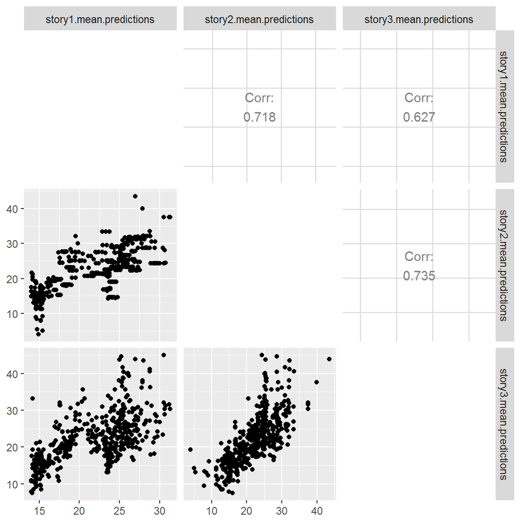

```r
ggpairs(allStories.predictions,diag = list("continuous"="blank"))
```

Finally, let’s stick them in a `lm` predicting the dependent variable. Did it work? Well if the final model predicts “better” then the individual story models or your own combined model, then yes.

```r
finalReg <- lm(log(BostonHousing2$cmedv) ~ .,data=allStories.predictions )
summary(finalReg)
```

```
##
## Call:
## lm(formula = log(BostonHousing2$cmedv) ~ ., data = allStories.predictions)
##
## Residuals:
##      Min       1Q   Median       3Q      Max
## -0.84190 -0.11225 -0.01167  0.09639  1.33357
##
## Coefficients:
##                          Estimate Std. Error t value Pr(>|t|)
## (Intercept)             1.8419668  0.0501347  36.740   <2e-16 ***
## story1.mean.predictions 0.0007504  0.0033437   0.224    0.823
## story2.mean.predictions 0.0212264  0.0030454   6.970    1e-11 ***
## story3.mean.predictions 0.0328393  0.0023954  13.709   <2e-16 ***
## ---
## Signif. codes:  0 '***' 0.001 '**' 0.01 '*' 0.05 '.' 0.1 ' ' 1
##
## Residual standard error: 0.2419 on 502 degrees of freedom
## Multiple R-squared:  0.6511, Adjusted R-squared:  0.6491
## F-statistic: 312.3 on 3 and 502 DF,  p-value: < 2.2e-16
```